# Logistic Regression

## 1. Reading data

```
## [1] 382  35
```

```
## 'data.frame':    382 obs. of  35 variables:
##  $ school    : Factor w/ 2 levels "GP","MS": 1 1 1 1 1 1 1 1 1 1 ...
##  $ sex       : Factor w/ 2 levels "F","M": 1 1 1 1 1 2 2 1 2 2 ...
##  $ age       : int  18 17 15 15 16 16 16 17 15 15 ...
##  $ address   : Factor w/ 2 levels "R","U": 2 2 2 2 2 2 2 2 2 2 ...
##  $ famsize   : Factor w/ 2 levels "GT3","LE3": 1 1 2 1 1 2 2 1 2 1 ...
##  $ Pstatus   : Factor w/ 2 levels "A","T": 1 2 2 2 2 2 2 1 1 2 ...
##  $ Medu      : int  4 1 1 4 3 4 2 4 3 3 ...
##  $ Fedu      : int  4 1 1 2 3 3 2 4 2 4 ...
##  $ Mjob      : Factor w/ 5 levels "at_home","health",..: 1 1 1 2 3 4 3 3 4 3 ...
##  $ Fjob      : Factor w/ 5 levels "at_home","health",..: 5 3 3 4 3 3 3 5 3 3 ...
##  $ reason    : Factor w/ 4 levels "course","home",..: 1 1 3 2 2 4 2 2 2 2 ...
##  $ nursery   : Factor w/ 2 levels "no","yes": 2 1 2 2 2 2 2 2 2 2 ...
##  $ internet  : Factor w/ 2 levels "no","yes": 1 2 2 2 1 2 2 1 2 2 ...
##  $ guardian  : Factor w/ 3 levels "father","mother",..: 2 1 2 2 1 2 2 2 2 2 ...
```

[output cut: 21 more lines]

### Summary of data

This dataset has 382 rows and 35 variables. There is general information about the students: school they belong to, sex, age, address and family size. There is also information about their parents, allocation of hours towards travel to school and studytime, some personal information about what the student is otherwise occupied with, health status (including alcohol consumption) and grades for Math and Portugese across 2 periods.

## 2. Hypothesis

Hypotheses to be tested 1. alcohol use is associated with the quality of family relationships. 2. alcohol use is associated with student’s freetime. 3. alcohol use is associated with health. 4. alcohol use is associated with sex.

## 3. Variable means

```
## # A tibble: 2 × 5
##   high_use count mean_famrel mean_freetime mean_health
##      <lgl> <int>       <dbl>         <dbl>       <dbl>
## 1    FALSE   270    4.014815      3.125926    3.518519
## 2     TRUE   112    3.758929      3.455357    3.723214
```

### Summary

Here, we see that there are 270 cases of low alcohol use and 112 cases of high alcohol use (more than 2 on a scale of 1-5). freetime - free time after school (numeric: from 1 - very low to 5 - very high) famrel - quality of family relationships (numeric: from 1 - very bad to 5 - excellent) health - current health status (numeric: from 1 - very bad to 5 - very good)

In the group of high alcohol use, the mean of quality of family relationships is 3.7 and for the group with low alcohol use, the mean of quality of family relationships is 4.0. In general, it can be surmised that low alcohol use may be associated with better family relationships.

Amongst students with low alcohol use, there is less free time (mean = 3.12) compared to students with higher alcohol use who seem to have more free time (mean = 3.46). Interestingly, low alcohol consumption students seem to enjoy worse health (mean = 3.5) than students who drink more (mean = 3.72)

## 4. Variable means by sex

```
## Source: local data frame [4 x 6]
## Groups: sex [?]
##
##      sex high_use count mean_famrel mean_freetime mean_health
##   <fctr>    <lgl> <int>       <dbl>         <dbl>       <dbl>
## 1      F    FALSE   157    3.917197      2.929936    3.388535
## 2      F     TRUE    41    3.731707      3.341463    3.390244
## 3      M    FALSE   113    4.150442      3.398230    3.699115
## 4      M     TRUE    71    3.774648      3.521127    3.915493
```

### Summary

With regards to sex, 157 females consume low amounts of alcohol and 41 females consume high amounts of alcohol. In the group of females who drink more, family relationship is worse ( 3.73), they have more freetime (mean=3.34) and they enjoy better health (3.39) as compared to females who drink less.

In the male group, there are 113 males who drink less and 71 males who drink more. The group that drinks more has less quality family relationships (mean=3.77), more freetime (mean=3.52) and also enjoy better healht (3.91) as compared to males who drink less. Males with high alcohol use have more free time and better family relationships and enjoy better health than females with high alcohol use.

## 5. Boxplots for selected variables

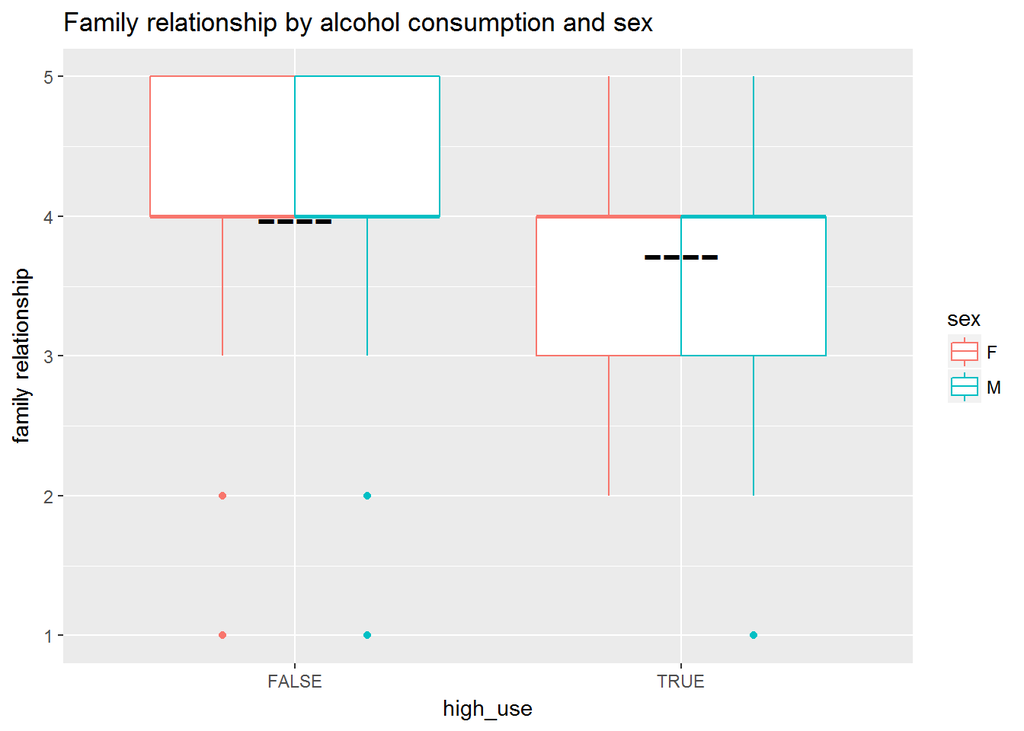

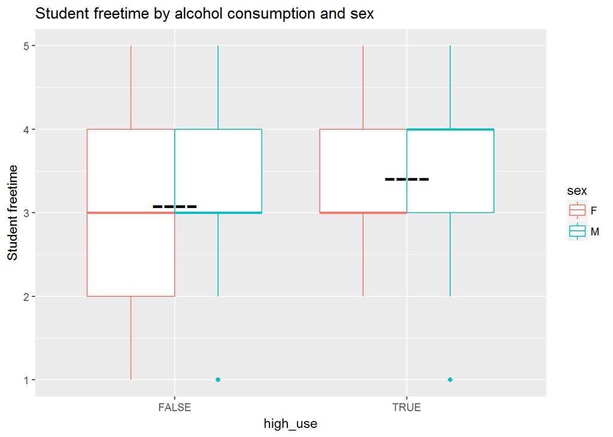

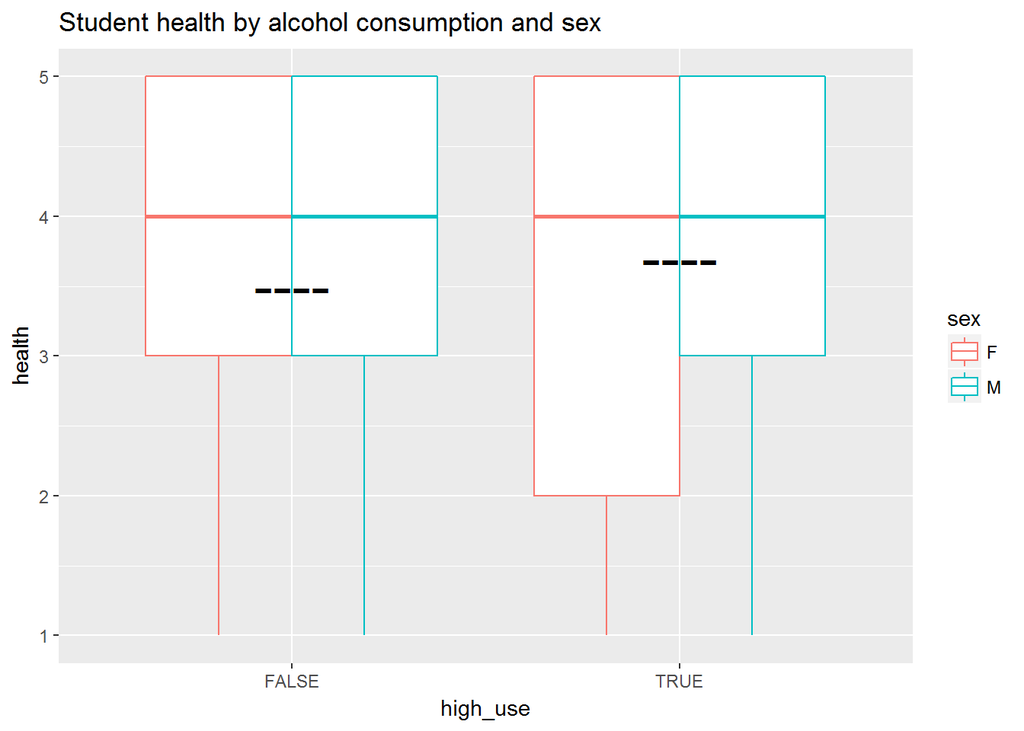

### Summary

The median for quality of family relationships is the same for both males and females across both groups of alcohol use (median = 4). The upper quartile value is 5 in both sexes for students with low alcohol use and 4 for students with high alcohol use. The lowest value for family relationship (ignoring the outliers) is 3 for students with low alcohol consumption and 2 for students with high alcohol consumption.

The median for student health is 4 for students with high and low alcohol use. Mean health is higher for students with high alcohol comsumption.

## 6. Barplots for selected variables

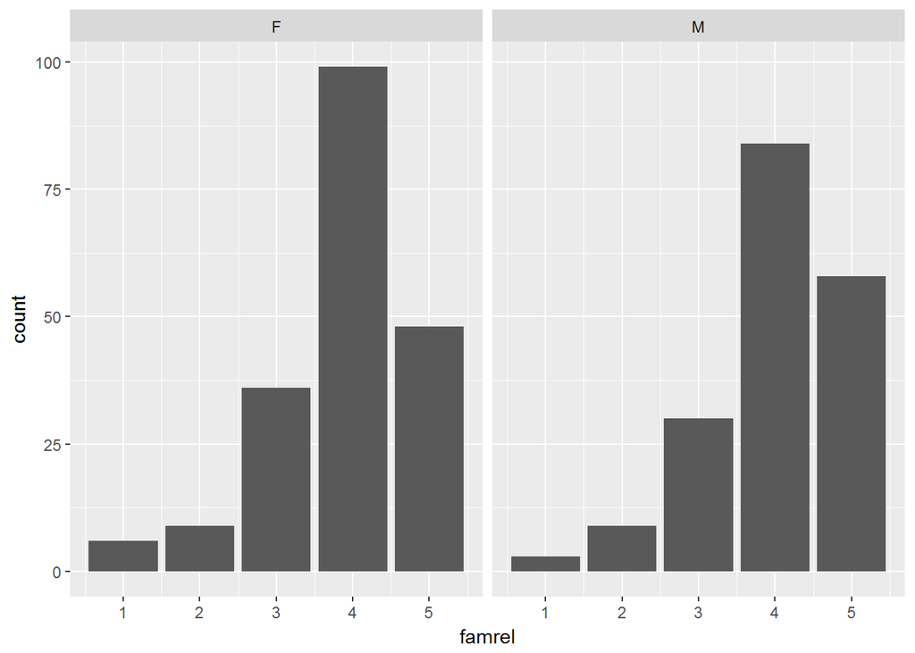

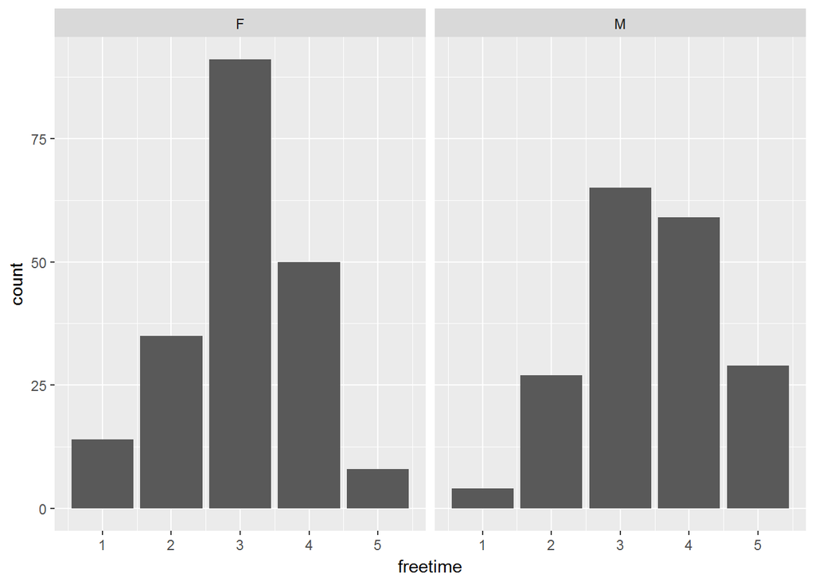

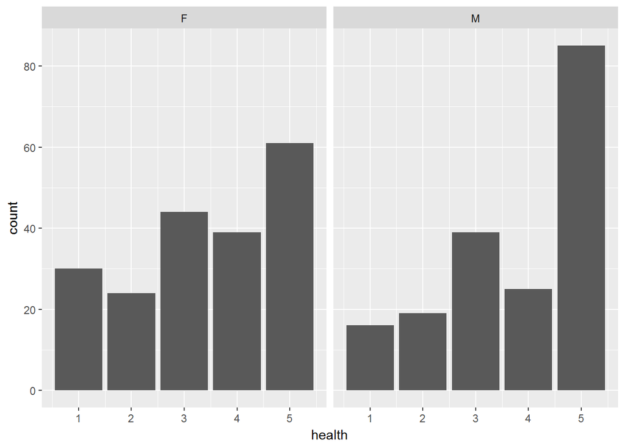

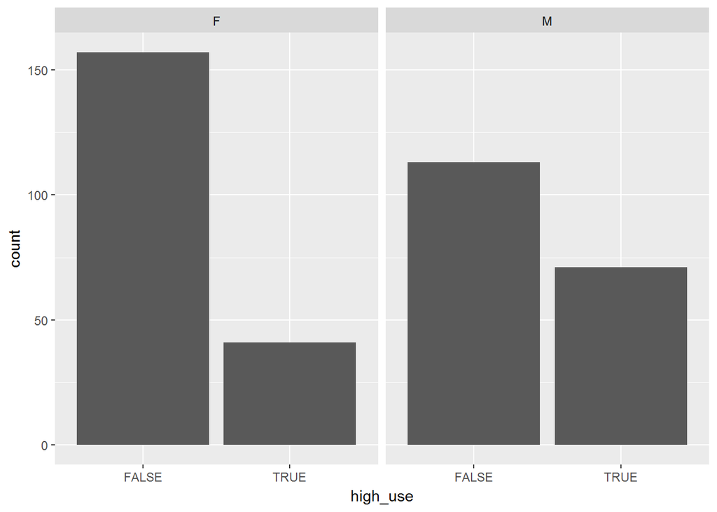

### Summary

The pattern for family relationship across sexes is the same. For freetime, the smallest number of females have the most freetime (5) and the smallest number of males have the lowest freetime (1). For health, the highest number of individuals have the healthiest status in both sexes. Across both sexes, there are more individuals with low alcohol use.

## 7. Regression model with selected variables (famrel + freetime + health + G1)

```
##
## Call:
## glm(formula = high_use ~ famrel + freetime + health + G1, family = "binomial",
##     data = alc)
##
## Deviance Residuals:
##     Min       1Q   Median       3Q      Max
## -1.4032  -0.8646  -0.6795   1.2523   2.1451
##
## Coefficients:
##             Estimate Std. Error z value Pr(>|z|)
## (Intercept) -0.38950    0.72807  -0.535 0.592670
## famrel      -0.38713    0.12645  -3.062 0.002202 **
## freetime     0.41644    0.12361   3.369 0.000755 ***
## health       0.11004    0.08564   1.285 0.198823
## G1          -0.07059    0.03575  -1.975 0.048308 *
## ---
## Signif. codes:  0 '***' 0.001 '**' 0.01 '*' 0.05 '.' 0.1 ' ' 1
##
## (Dispersion parameter for binomial family taken to be 1)
##
##     Null deviance: 462.21  on 381  degrees of freedom
## Residual deviance: 438.17  on 377  degrees of freedom
## AIC: 448.17
##
## Number of Fisher Scoring iterations: 4
```

```
## (Intercept)      famrel    freetime      health          G1
## -0.38949538 -0.38713461  0.41643988  0.11003943 -0.07059407
```

```
##                    OR     2.5 %    97.5 %
## (Intercept) 0.6773986 0.1612150 2.8229159
## famrel      0.6789997 0.5284166 0.8690777
## freetime    1.5165528 1.1947907 1.9419266
## health      1.1163221 0.9456039 1.3238873
## G1          0.9318401 0.8678501 0.9987250
```

### Summary

Family relationship and first period scores are negatively associated with alcohol consumption and student freetime is positively associated with alcohol consumption. There is no association between student health and alcohol consumption.

## 8. Regression model with selected variables (famrel + freetime + sex + G1)

```
##
## Call:
## glm(formula = high_use ~ famrel + freetime + sex + G1, family = "binomial",
##     data = alc)
##
## Deviance Residuals:
##     Min       1Q   Median       3Q      Max
## -1.4430  -0.8247  -0.6293   1.1380   2.2757
##
## Coefficients:
##             Estimate Std. Error z value Pr(>|z|)
## (Intercept)  0.06816    0.68428   0.100 0.920658
## famrel      -0.39708    0.12768  -3.110 0.001871 **
## freetime     0.33524    0.12611   2.658 0.007851 **
## sexM         0.91114    0.24671   3.693 0.000222 ***
## G1          -0.09231    0.03668  -2.517 0.011842 *
## ---
## Signif. codes:  0 '***' 0.001 '**' 0.01 '*' 0.05 '.' 0.1 ' ' 1
##
## (Dispersion parameter for binomial family taken to be 1)
##
##     Null deviance: 462.21  on 381  degrees of freedom
## Residual deviance: 425.75  on 377  degrees of freedom
## AIC: 435.75
##
## Number of Fisher Scoring iterations: 4
```

```
## (Intercept)      famrel    freetime        sexM          G1
##  0.06815784 -0.39708257  0.33524348  0.91114399 -0.09231233
```

```
##                    OR     2.5 %    97.5 %
## (Intercept) 1.0705343 0.2775903 4.0995202
## famrel      0.6722785 0.5218210 0.8623343
## freetime    1.3982808 1.0955471 1.7982556
## sexM        2.4871662 1.5412350 4.0616884
## G1          0.9118203 0.8474427 0.9788147
```

### Summary

Family relationships and period 1 scores are negatively associated with alcohol use i.e. the lower the quality of family relationships, the higher the alcohol use. The most significant association is sex. With sex=females as the baseline in the intercept, the coefficient for males is 0.06 + 0.91=0.97. In summary, family relationships, student freetime, sex and period 1 scores are are significantly associated with high alcohol use.

## 9. predictions versus the actual values

```
##
##         FALSE TRUE
##   FALSE   250   20
##   TRUE     94   18
```

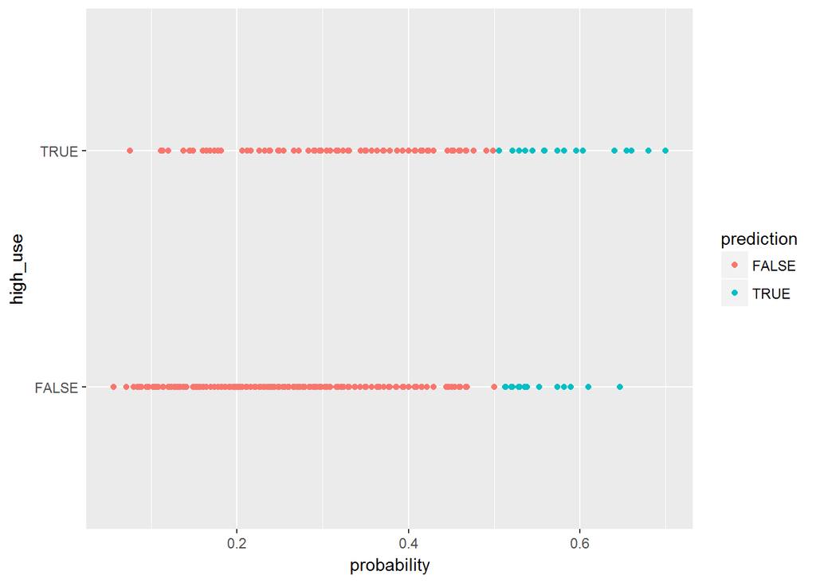

## 10. Percentage predictions accuracy

```
##         prediction
## high_use      FALSE       TRUE        Sum
##    FALSE 0.65445026 0.05235602 0.70680628
##    TRUE  0.24607330 0.04712042 0.29319372
##    Sum   0.90052356 0.09947644 1.00000000
```

### Summary

Predition error is 30% (0.25 + 0.05) of the time.